# Bikesharing Visualization slides

## Ford GoBike Data Visualization and Analysis

### Introduction

> This project is analyzing the Ford GoBike system data from 2018-1 to 2018-10. The goal of the project is to explore some insights about the trip and user and help team make the decision about the operations and marketing strategy.

### Table of Content

1. Questions
2. Data Wrangling
3. Data Visualization
4. Insights and Conclusions

## 1. Questions

1. What's the demographic of users?
2. What's the most popular station to pick up and return the bike?
3. What's the use pattern of rides.

## Data Visualization and Analysis

Question 1: What's the demographic of users?

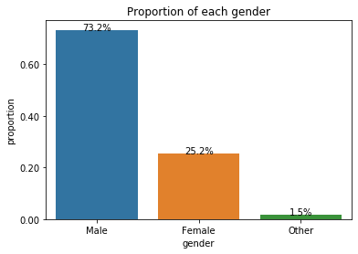

```python
# User Information
n_points=bike.shape[0]
max_count=bike.member_gender.value_counts().max()
max_prop=max_count/n_points

# Generate tick mark locations and names
tick_props=np.arange(0, max_prop, 0.2)
tick_names=['{:0.2f}'.format(v) for v in tick_props]

# create plot

sns.countplot(data=bike, x='member_gender')
plt.yticks(tick_props*n_points, tick_names)
plt.ylabel('proportion')
plt.xlabel('gender')
plt.title('Proportion of each gender')


# Add annotation
gender_count=bike.member_gender.value_counts()
locs, labels=plt.xticks()

for loc, label in zip(locs, labels):
    count = gender_count[label.get_text()]
    pct_string = '{:0.1f}%'.format(100*count/n_points)

    # print the annotation just below the top of the bar
    plt.text(loc, count, pct_string, ha = 'center', color = 'black')
```

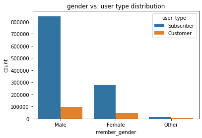

```python
sns.countplot(data=bike, x='member_gender', hue='user_type')
plt.title("gender vs. user type distribution")
```

Here, we can conclude that the subscriber accounts for 80% of each gender, so we need to take more effort to the user experience of subscriber to improve the user retention.

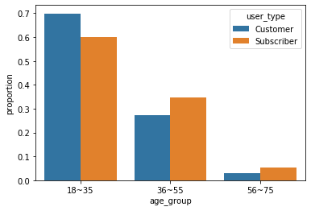

```python
x, y, hue = "age_group", "proportion", "user_type"

(bike[x]
 .groupby(bike[hue])
 .value_counts(normalize=True)
 .rename(y)
 .reset_index()
 .pipe((sns.barplot, "data"), x=x, y=y, hue=hue))
```

In the graph, we can see that about 70% of customers are from 18 ~ 35 age group, 28% of customers are from 36 ~ 55 age group. 60% subscribers are from 18 ~ 35 age group and about 35% of subsribers are from 36 ~ 55 age group. Thus, we can conclude that the proportion of subscriber in 36 ~ 55 age group is higher than the proportion of subscriber in 18 ~ 35 group. It could easier to convert a customer to a subscriber in 36 ~ 55 age group.

Question 2: What's the use pattern of rides?

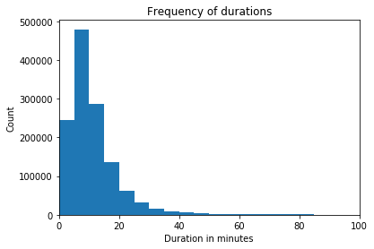

```python
## 1. Check the distribution of duration minutes
bins=np.arange(0, bike.duration_mins.max()+5, 5)

plt.hist(bike.duration_mins, bins=bins)
plt.xlim(0,100)
plt.xlabel("Duration in minutes")
plt.ylabel("Count")
plt.title("Frequency of durations")
```

In this chart, we can see that the duration of most trips are less than 20 mins; Most of users spend 5 minutes to 10 minutes for each trip.

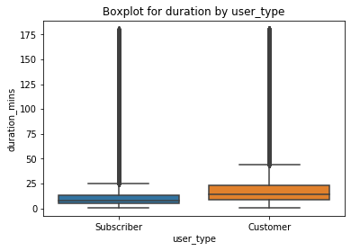

```python
## Duration for different user type
sns.boxplot(data=bike, x='user_type',y='duration_mins')
plt.title("Boxplot for duration by user_type")
```

The median duration of customer is 14 mins which is higher than median duration of subscriber 8 mins. We can dive deep about this observation to see the reason behind, possible reason could be: customer use the bike on occasion to arrive somewhere without walking distance, whereas subscriber usually has the fixed route to go.

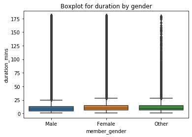

```python
# Check the duration for different gender
sns.boxplot(data=bike, x='member_gender', y='duration_mins')
plt.title("Boxplot for duration by gender")
```

In this boxplot chart, we can see the median duration for female 10 minutes is higher than median duration for male 8 mins.

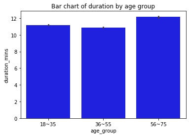

```python
# Check the duration for different age group
sns.barplot(data=bike, x='age_group', y='duration_mins', color='blue')
plt.title("Bar chart of duration by age group")
```

```python
bike.member_gender.value_counts()
```

```
Male      944456
Female    325540
Other      19626
Name: member_gender, dtype: int64
```

We can see that 56 ~ 75 age group has the higest duration, and then 18 ~ 35 group; 36 ~ 55 age group has the lowest average duration for each trip.

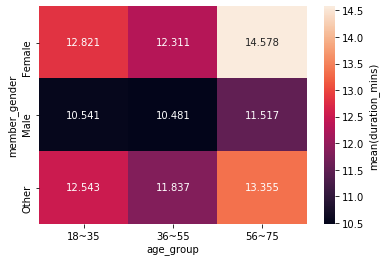

```python
# Heatmap for different age_group and gender
cat_means = bike.groupby(['age_group', 'member_gender']).mean()['duration_mins']
cat_means = cat_means.reset_index(name = 'mean_duration_mins')
cat_means = cat_means.pivot(index = 'member_gender', columns = 'age_group',
                            values = 'mean_duration_mins')
sns.heatmap(cat_means, annot = True, fmt = '.3f',
           cbar_kws = {'label' : 'mean(duration_mins)'})
```

Here, we can see that mean duration for 18 ~ 35 and 36~ 55 age group for male are almost the same, the average duaration for each trip is 10.5 minutes. The highest average duration happens in the female in 56 ~ 75 age group. On average, in the same age group, female user usually spend 2 more minutes than male user. This may result in the higher fee charged from female user than male user if we charge the fee by total time spent. Thus, I recommend that we can take both mileage and time spent into consideration to charge the fee.

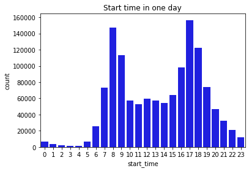

```python
# Check the peak time to use the bike.
sns.countplot(bike.start_time.dt.hour, color='blue')
plt.title("Start time in one day")
```

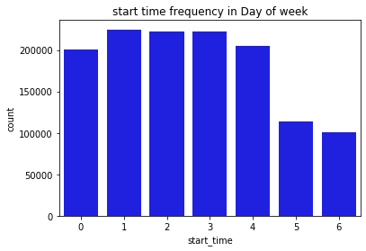

```python
# Check which day that the bikes get highest usage.
sns.countplot(bike.start_time.dt.weekday, color='blue')

#labels=['sun','mon','tue','wed','thu','fri','sat']
plt.xticks(x=bike.start_time.dt.weekday)
plt.title("start time frequency in Day of week")
```

From this image, we can see 7:00 ~ 9:00 and 16:00 ~ 18:00 are the peak time to use bike sharing, and it aligns with the morning rush hour so I can assume most frequent use cases is to commute. The bikes get the highest usage during weekday, which is again, prove that the most frequent use case is for people to commute.

Question 3: What' the most popular station to pick up and return the bike?

```python
sf_map_1
```

[interactive chart not shown]

```python
sf_map_2
```

[interactive chart not shown]

In this heatmap, we can see that the trip start station are centrated on San Francisco, Oakland and San Jose. That makes sense since the density of office buildings in these 3 area is very high. Thus, in this 3 area, we need to improve the bike inspection frequently here to make sure we provide enough amount of bikes in good quality.

### Conclusions

Given the insight we generated from the analysis, I think we can have some improvement about the marketing strategy and operations.

- In the San Francisco, Berkely, Oakland and San Jose area we can build more bike stations and put more bikes there for make sure we provide enough amount of bikes.
- Especially during weekday morning and evening, we need to make sure the enough supply for people since the most frequent use cases for user is to commute for work.
- Since male users account for a large amount of our users, we can put more marketing budget and resources focus to the male customer.
- The difference average duration between male and femal user may result in the higher fee charged from female user than male user if we charge the fee by total time spent. Thus, I recommend that we can take both mileage and time spent into consideration to charge the fee.